# Part I - Proster Loan Data

## Introduction

This [data set](https://s3.amazonaws.com/udacity-hosted-downloads/ud651/prosperLoanData.csv) contains 113,937 loans with 81 variables on each loan, including loan amount, borrower rate (or interest rate), current loan status, borrower income, and many others.

This data dictionary explains the variables in the data set.

## Preliminary Wrangling

```python
# import all packages and set plots to be embedded inline
import numpy as np
import pandas as pd
import matplotlib.pyplot as plt
import seaborn as sns

# hide warnings
import warnings
warnings.filterwarnings('ignore')

%matplotlib inline
```

```python
# load in the dataset into a pandas dataframe
loan_data = pd.read_csv('prosperLoanData.csv')
loan_data
```

|  | ListingKey | ListingNumber | ListingCreationDate | CreditGrade | Term | LoanStatus | ClosedDate | BorrowerAPR | BorrowerRate | LenderYield | ... | LP_ServiceFees | LP_CollectionFees | LP_GrossPrincipalLoss | LP_NetPrincipalLoss | LP_NonPrincipalRecoverypayments | PercentFunded | Recommendations | InvestmentFromFriendsCount | InvestmentFromFriendsAmount | Investors |
| --- | --- | --- | --- | --- | --- | --- | --- | --- | --- | --- | --- | --- | --- | --- | --- | --- | --- | --- | --- | --- | --- |
| 0 | 1021339766868145413AB3B | 193129 | 2007-08-26 19:09:29.263000000 | C | 36 | Completed | 2009-08-14 00:00:00 | 0.16516 | 0.1580 | 0.1380 | ... | -133.18 | 0.0 | 0.0 | 0.0 | 0.0 | 1.0 | 0 | 0 | 0.0 | 258 |
| 1 | 10273602499503308B223C1 | 1209647 | 2014-02-27 08:28:07.900000000 | NaN | 36 | Current | NaN | 0.12016 | 0.0920 | 0.0820 | ... | 0.00 | 0.0 | 0.0 | 0.0 | 0.0 | 1.0 | 0 | 0 | 0.0 | 1 |
| 2 | 0EE9337825851032864889A | 81716 | 2007-01-05 15:00:47.090000000 | HR | 36 | Completed | 2009-12-17 00:00:00 | 0.28269 | 0.2750 | 0.2400 | ... | -24.20 | 0.0 | 0.0 | 0.0 | 0.0 | 1.0 | 0 | 0 | 0.0 | 41 |
| 3 | 0EF5356002482715299901A | 658116 | 2012-10-22 11:02:35.010000000 | NaN | 36 | Current | NaN | 0.12528 | 0.0974 | 0.0874 | ... | -108.01 | 0.0 | 0.0 | 0.0 | 0.0 | 1.0 | 0 | 0 | 0.0 | 158 |
| 4 | 0F023589499656230C5E3E2 | 909464 | 2013-09-14 18:38:39.097000000 | NaN | 36 | Current | NaN | 0.24614 | 0.2085 | 0.1985 | ... | -60.27 | 0.0 | 0.0 | 0.0 | 0.0 | 1.0 | 0 | 0 | 0.0 | 20 |
| ... | ... | ... | ... | ... | ... | ... | ... | ... | ... | ... | ... | ... | ... | ... | ... | ... | ... | ... | ... | ... | ... |
| 113932 | E6D9357655724827169606C | 753087 | 2013-04-14 05:55:02.663000000 | NaN | 36 | Current | NaN | 0.22354 | 0.1864 | 0.1764 | ... | -75.58 | 0.0 | 0.0 | 0.0 | 0.0 | 1.0 | 0 | 0 | 0.0 | 1 |
| 113933 | E6DB353036033497292EE43 | 537216 | 2011-11-03 20:42:55.333000000 | NaN | 36 | FinalPaymentInProgress | NaN | 0.13220 | 0.1110 | 0.1010 | ... | -30.05 | 0.0 | 0.0 | 0.0 | 0.0 | 1.0 | 0 | 0 | 0.0 | 22 |
| 113934 | E6E13596170052029692BB1 | 1069178 | 2013-12-13 05:49:12.703000000 | NaN | 60 | Current | NaN | 0.23984 | 0.2150 | 0.2050 | ... | -16.91 | 0.0 | 0.0 | 0.0 | 0.0 | 1.0 | 0 | 0 | 0.0 | 119 |
| 113935 | E6EB3531504622671970D9E | 539056 | 2011-11-14 13:18:26.597000000 | NaN | 60 | Completed | 2013-08-13 00:00:00 | 0.28408 | 0.2605 | 0.2505 | ... | -235.05 | 0.0 | 0.0 | 0.0 | 0.0 | 1.0 | 0 | 0 | 0.0 | 274 |
| 113936 | E6ED3600409833199F711B7 | 1140093 | 2014-01-15 09:27:37.657000000 | NaN | 36 | Current | NaN | 0.13189 | 0.1039 | 0.0939 | ... | -1.70 | 0.0 | 0.0 | 0.0 | 0.0 | 1.0 | 0 | 0 | 0.0 | 1 |

113937 rows × 81 columns

```python
dictionary = pd.read_csv("dictionary.csv",sep=';')
dictionary
```

|  | Variable | Description |
| --- | --- | --- |
| 0 | ListingKey | Unique key for each listing, same value as the... |
| 1 | ListingNumber | The number that uniquely identifies the listin... |
| 2 | ListingCreationDate | The date the listing was created. |
| 3 | CreditGrade | The Credit rating that was assigned at the tim... |
| 4 | Term | The length of the loan expressed in months. |
| ... | ... | ... |
| 76 | PercentFunded | Percent the listing was funded. |
| 77 | Recommendations | Number of recommendations the borrower had at ... |
| 78 | InvestmentFromFriendsCount | Number of friends that made an investment in t... |
| 79 | InvestmentFromFriendsAmount | Dollar amount of investments that were made by... |
| 80 | Investors | The number of investors that funded the loan. |

81 rows × 2 columns

```python
# print data shape
print(loan_data.shape)
```

```
(113937, 81)
```

```python
loan_data.info()
```

```
<class 'pandas.core.frame.DataFrame'>
RangeIndex: 113937 entries, 0 to 113936
Data columns (total 81 columns):
 #   Column                               Non-Null Count   Dtype
---  ------                               --------------   -----
 0   ListingKey                           113937 non-null  object
 1   ListingNumber                        113937 non-null  int64
 2   ListingCreationDate                  113937 non-null  object
 3   CreditGrade                          28953 non-null   object
 4   Term                                 113937 non-null  int64
 5   LoanStatus                           113937 non-null  object
 6   ClosedDate                           55089 non-null   object
 7   BorrowerAPR                          113912 non-null  float64
 8   BorrowerRate                         113937 non-null  float64
 9   LenderYield                          113937 non-null  float64
```

[output cut: 73 more lines]

```python
# descriptive statistics for numeric variables
loan_data.describe()
```

|  | ListingNumber | Term | BorrowerAPR | BorrowerRate | LenderYield | EstimatedEffectiveYield | EstimatedLoss | EstimatedReturn | ProsperRating (numeric) | ProsperScore | ... | LP_ServiceFees | LP_CollectionFees | LP_GrossPrincipalLoss | LP_NetPrincipalLoss | LP_NonPrincipalRecoverypayments | PercentFunded | Recommendations | InvestmentFromFriendsCount | InvestmentFromFriendsAmount | Investors |
| --- | --- | --- | --- | --- | --- | --- | --- | --- | --- | --- | --- | --- | --- | --- | --- | --- | --- | --- | --- | --- | --- |
| count | 1.139370e+05 | 113937.000000 | 113912.000000 | 113937.000000 | 113937.000000 | 84853.000000 | 84853.000000 | 84853.000000 | 84853.000000 | 84853.000000 | ... | 113937.000000 | 113937.000000 | 113937.000000 | 113937.000000 | 113937.000000 | 113937.000000 | 113937.000000 | 113937.000000 | 113937.000000 | 113937.000000 |
| mean | 6.278857e+05 | 40.830248 | 0.218828 | 0.192764 | 0.182701 | 0.168661 | 0.080306 | 0.096068 | 4.072243 | 5.950067 | ... | -54.725641 | -14.242698 | 700.446342 | 681.420499 | 25.142686 | 0.998584 | 0.048027 | 0.023460 | 16.550751 | 80.475228 |
| std | 3.280762e+05 | 10.436212 | 0.080364 | 0.074818 | 0.074516 | 0.068467 | 0.046764 | 0.030403 | 1.673227 | 2.376501 | ... | 60.675425 | 109.232758 | 2388.513831 | 2357.167068 | 275.657937 | 0.017919 | 0.332353 | 0.232412 | 294.545422 | 103.239020 |
| min | 4.000000e+00 | 12.000000 | 0.006530 | 0.000000 | -0.010000 | -0.182700 | 0.004900 | -0.182700 | 1.000000 | 1.000000 | ... | -664.870000 | -9274.750000 | -94.200000 | -954.550000 | 0.000000 | 0.700000 | 0.000000 | 0.000000 | 0.000000 | 1.000000 |
| 25% | 4.009190e+05 | 36.000000 | 0.156290 | 0.134000 | 0.124200 | 0.115670 | 0.042400 | 0.074080 | 3.000000 | 4.000000 | ... | -73.180000 | 0.000000 | 0.000000 | 0.000000 | 0.000000 | 1.000000 | 0.000000 | 0.000000 | 0.000000 | 2.000000 |
| 50% | 6.005540e+05 | 36.000000 | 0.209760 | 0.184000 | 0.173000 | 0.161500 | 0.072400 | 0.091700 | 4.000000 | 6.000000 | ... | -34.440000 | 0.000000 | 0.000000 | 0.000000 | 0.000000 | 1.000000 | 0.000000 | 0.000000 | 0.000000 | 44.000000 |
| 75% | 8.926340e+05 | 36.000000 | 0.283810 | 0.250000 | 0.240000 | 0.224300 | 0.112000 | 0.116600 | 5.000000 | 8.000000 | ... | -13.920000 | 0.000000 | 0.000000 | 0.000000 | 0.000000 | 1.000000 | 0.000000 | 0.000000 | 0.000000 | 115.000000 |
| max | 1.255725e+06 | 60.000000 | 0.512290 | 0.497500 | 0.492500 | 0.319900 | 0.366000 | 0.283700 | 7.000000 | 11.000000 | ... | 32.060000 | 0.000000 | 25000.000000 | 25000.000000 | 21117.900000 | 1.012500 | 39.000000 | 33.000000 | 25000.000000 | 1189.000000 |

8 rows × 61 columns

### What is the structure of your dataset?

There are 113937 cases of loan in the dataset with 81 features. Most variables are numeric (61), but the categorical variables are present as well.

### What is/are the main feature(s) of interest in your dataset?

I would like to know which borrower information is correlated to Prosper Score. In particular, the following properties might be interesting:

1. `ListingCategory (numeric)`

The category of the listing that the borrower selected when posting their listing: 0 - Not Available, 1 - Debt Consolidation, 2 - Home Improvement, 3 - Business, 4 - Personal Loan, 5 - Student Use, 6 - Auto, 7- Other, 8 - Baby&Adoption, 9 - Boat, 10 - Cosmetic Procedure, 11 - Engagement Ring, 12 - Green Loans, 13 - Household Expenses, 14 - Large Purchases, 15 - Medical/Dental, 16 - Motorcycle, 17 - RV, 18 - Taxes, 19 - Vacation, 20 - Wedding Loans.

1. `EmploymentStatusDuration`

The length in months of the employment status at the time the listing was created.

1. `EmploymentStatus`

The employment status of the borrower at the time they posted the listing.

1. `ProsperScore`

1. `CurrentCreditLines`

Number of current credit lines at the time the credit profile was pulled.

1. `IncomeVerifiable`

The borrower indicated they have the required documentation to support their income.

1. `LoanOriginalAmount`

The origination amount of the loan.

1. `LoanStatus`

The current status of the loan.

### What features in the dataset do you think will help support your investigation into your feature(s) of interest?

I think Loan Original Amount should be highly correlated to Prosper Score. Information on Employment Status & Employment status duration may be of great impact as well. Finally, Loan Status might provide some information on Prosper Score as well.

## Data Wrangling

`ListingCategory` is numeric, the values are not explicit, we will need to transform them to categorical data

```python
# Transform ListingCategory (numeric) feature into categorical
list_dict = {0 : 'Not Available', 1 : 'Debt Consolidation', 2 : 'Home Improvement', 3: 'Business',
             4 : 'Personal Loan', 5 : 'Student Use', 6 : 'Auto', 7 : 'Other', 8 : 'Baby&Adoption',
             9 : 'Boat', 10 : 'Cosmetic Procedure', 11 : 'Engagement Ring', 12 : 'Green Loans',
             13 : 'Household Expenses', 14 : 'Large Purchases', 15 : 'Medical/Dental', 16 : 'Motorcycle',
             17 : 'RV', 18 : 'Taxes', 19 : 'Vacation', 20 : 'Wedding Loans'}

loan_data['ListingCategory (numeric)'] = loan_data['ListingCategory (numeric)'].replace(list_dict)

loan_data['ListingCategory (numeric)'].dtype
```

```
dtype('O')
```

Since Listing Category is not numeric any longer, we will rename this column

```python
loan_data.rename(columns={'ListingCategory (numeric)':'ListingCategory'},inplace=True)
loan_data.columns
```

```
Index(['ListingKey', 'ListingNumber', 'ListingCreationDate', 'CreditGrade',
       'Term', 'LoanStatus', 'ClosedDate', 'BorrowerAPR', 'BorrowerRate',
       'LenderYield', 'EstimatedEffectiveYield', 'EstimatedLoss',
       'EstimatedReturn', 'ProsperRating (numeric)', 'ProsperRating (Alpha)',
       'ProsperScore', 'ListingCategory', 'BorrowerState', 'Occupation',
       'EmploymentStatus', 'EmploymentStatusDuration', 'IsBorrowerHomeowner',
       'CurrentlyInGroup', 'GroupKey', 'DateCreditPulled',
       'CreditScoreRangeLower', 'CreditScoreRangeUpper',
       'FirstRecordedCreditLine', 'CurrentCreditLines', 'OpenCreditLines',
       'TotalCreditLinespast7years', 'OpenRevolvingAccounts',
       'OpenRevolvingMonthlyPayment', 'InquiriesLast6Months', 'TotalInquiries',
       'CurrentDelinquencies', 'AmountDelinquent', 'DelinquenciesLast7Years',
       'PublicRecordsLast10Years', 'PublicRecordsLast12Months',
       'RevolvingCreditBalance', 'BankcardUtilization',
       'AvailableBankcardCredit', 'TotalTrades',
       'TradesNeverDelinquent (percentage)', 'TradesOpenedLast6Months',
       'DebtToIncomeRatio', 'IncomeRange', 'IncomeVerifiable',
       'StatedMonthlyIncome', 'LoanKey', 'TotalProsperLoans',
       'TotalProsperPaymentsBilled', 'OnTimeProsperPayments',
       'ProsperPaymentsLessThanOneMonthLate',
       'ProsperPaymentsOneMonthPlusLate', 'ProsperPrincipalBorrowed',
       'ProsperPrincipalOutstanding', 'ScorexChangeAtTimeOfListing',
       'LoanCurrentDaysDelinquent', 'LoanFirstDefaultedCycleNumber',
       'LoanMonthsSinceOrigination', 'LoanNumber', 'LoanOriginalAmount',
       'LoanOriginationDate', 'LoanOriginationQuarter', 'MemberKey',
       'MonthlyLoanPayment', 'LP_CustomerPayments',
       'LP_CustomerPrincipalPayments', 'LP_InterestandFees', 'LP_ServiceFees',
       'LP_CollectionFees', 'LP_GrossPrincipalLoss', 'LP_NetPrincipalLoss',
       'LP_NonPrincipalRecoverypayments', 'PercentFunded', 'Recommendations',
       'InvestmentFromFriendsCount', 'InvestmentFromFriendsAmount',
       'Investors'],
      dtype='object')
```

We will also transform IncomeVerifiable and Prosper Score to object data type

```python
loan_data = loan_data.astype({"IncomeVerifiable": "category","ProsperScore": "category"})
print(loan_data['IncomeVerifiable'].dtype)
print(loan_data['ProsperScore'].dtype)
```

```
category
category
```

There are a lot of columns we don't need for our analysis, we will keep only the columns of interest

```python
#keep only columns we are interested in

data = loan_data[['ListingCategory','EmploymentStatusDuration','EmploymentStatus',
            'ProsperScore','CurrentCreditLines','IncomeVerifiable','LoanOriginalAmount','LoanStatus']]

print(data.shape)
data.head()
```

```
(113937, 8)
```

|  | ListingCategory | EmploymentStatusDuration | EmploymentStatus | ProsperScore | CurrentCreditLines | IncomeVerifiable | LoanOriginalAmount | LoanStatus |
| --- | --- | --- | --- | --- | --- | --- | --- | --- |
| 0 | Not Available | 2.0 | Self-employed | NaN | 5.0 | True | 9425 | Completed |
| 1 | Home Improvement | 44.0 | Employed | 7.0 | 14.0 | True | 10000 | Current |
| 2 | Not Available | NaN | Not available | NaN | NaN | True | 3001 | Completed |
| 3 | Motorcycle | 113.0 | Employed | 9.0 | 5.0 | True | 10000 | Current |
| 4 | Home Improvement | 44.0 | Employed | 4.0 | 19.0 | True | 15000 | Current |

We still have the same amount of rows, but only 8 columns for exploratory data analysis

## Univariate Exploration

In this section, we will investigate distributions of individual variables.

```python
# we will set the default color for plots
color = sns.color_palette()[0]
```

### ProsperScore

We will start by looking the distribution of our variable of interest, Prosper Score

```python
prosper_score = data['ProsperScore'].value_counts()

prosper_score_rel = data['ProsperScore'].value_counts(normalize=True)
prosper_score_rel
```

```
4.0     0.148433
6.0     0.144697
8.0     0.142046
7.0     0.124887
5.0     0.115647
3.0     0.090062
9.0     0.081447
2.0     0.067953
10.0    0.055979
11.0    0.017159
1.0     0.011691
Name: ProsperScore, dtype: float64
```

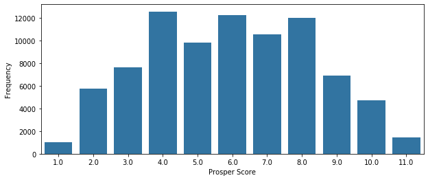

```python
plt.figure(figsize=[10,4])
sns.barplot(prosper_score.index.values, prosper_score, color=color)
plt.xlabel('Prosper Score')
plt.ylabel('Frequency');
```

Prosper Score is almost normally distributed - it has the highest frequencies between the values 4 and 8, wheareas scores 1 and 11 are less numerous.

Now we will check up the predictor variables

### LoanStatus

How Loan Status data is distributed?

```python
loan_status = data['LoanStatus'].value_counts()

loan_status_rel = data['LoanStatus'].value_counts(normalize=True)
loan_status_rel
```

```
Current                   0.496555
Completed                 0.334167
Chargedoff                0.105251
Defaulted                 0.044042
Past Due (1-15 days)      0.007074
Past Due (31-60 days)     0.003186
Past Due (61-90 days)     0.002747
Past Due (91-120 days)    0.002668
Past Due (16-30 days)     0.002326
FinalPaymentInProgress    0.001799
Past Due (>120 days)      0.000140
Cancelled                 0.000044
Name: LoanStatus, dtype: float64
```

We can see that there may be a lot of different values for Past Due status, which are not interesting for this study, we will replace these values only with Past Due.

Moreover, Cancelled, Final Payment In Progress status seem to have few data available, these data can be dropped.

```python
data['LoanStatus'] = data['LoanStatus'].str.replace(r'(Past Due).*',r'\1')

loan_status_rel = data['LoanStatus'].value_counts(normalize=True)
loan_status_rel
```

```
Current                   0.496555
Completed                 0.334167
Chargedoff                0.105251
Defaulted                 0.044042
Past Due                  0.018142
FinalPaymentInProgress    0.001799
Cancelled                 0.000044
Name: LoanStatus, dtype: float64
```

```python
data = data[data['LoanStatus'] != 'Cancelled']
data = data[data['LoanStatus'] != 'FinalPaymentInProgress']

loan_status = data['LoanStatus'].value_counts()

loan_status_rel = data['LoanStatus'].value_counts(normalize=True)
loan_status_rel
```

```
Current       0.497472
Completed     0.334784
Chargedoff    0.105445
Defaulted     0.044123
Past Due      0.018175
Name: LoanStatus, dtype: float64
```

```python
data.shape
```

```
(113727, 8)
```

210 rows were dropped after this step.

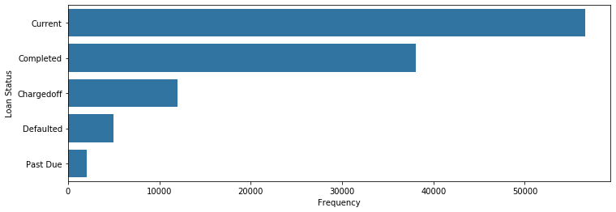

```python
plt.figure(figsize=[12,4])
sns.barplot(loan_status, loan_status.index.values, color=color)
plt.xlabel('Frequency')
plt.ylabel('Loan Status');
```

Current Loan Status represents almost 50% of data, Completed, Charged off, Defaulted are less numerous. Finally, Past Due is the least represented.

### ListingCategory

What values do we find in `ListingCategory` and how are they distributed?

```python
listing_categories = data['ListingCategory'].value_counts()

listing_categories_rel = data['ListingCategory'].value_counts(normalize=True)
listing_categories_rel
```

```
Debt Consolidation    0.511681
Not Available         0.149138
Other                 0.092080
Home Improvement      0.065218
Business              0.063090
Auto                  0.022536
Personal Loan         0.021059
Household Expenses    0.017498
Medical/Dental        0.013374
Taxes                 0.007755
Large Purchases       0.007650
Wedding Loans         0.006753
Vacation              0.006700
Student Use           0.006647
Motorcycle            0.002664
Engagement Ring       0.001890
Baby&Adoption         0.001750
Cosmetic Procedure    0.000800
Boat                  0.000747
Green Loans           0.000510
RV                    0.000457
Name: ListingCategory, dtype: float64
```

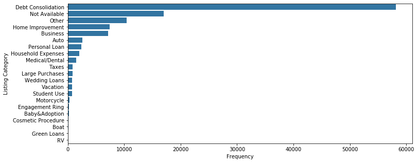

```python
plt.figure(figsize=[12,5])
sns.barplot(listing_categories, listing_categories.index.values, color=color)
plt.xlabel('Frequency')
plt.ylabel('Listing Category');
```

There is a lot of variance in Listing Category distribution. While there are 21 unique values for listing category, the debt consolidation represents more than 50% of data. Unfortunately, Not Available and Other are the 2d and the 3d most represented category, before Home Improvement, Business and Auto, which are less numerous. At this stage I'm not sure if such a skewed distribution would be of interest for further analysis.

### EmploymentStatus

What values may be encountered in Employment Status column and how they are distributed?

```python
employment_status = data['EmploymentStatus'].value_counts()

employment_status_rel = data['EmploymentStatus'].value_counts(normalize=True)
employment_status_rel
```

```
Employed         0.602332
Full-time        0.236322
Self-employed    0.054936
Not available    0.047957
Other            0.034070
Part-time        0.009760
Not employed     0.007490
Retired          0.007132
Name: EmploymentStatus, dtype: float64
```

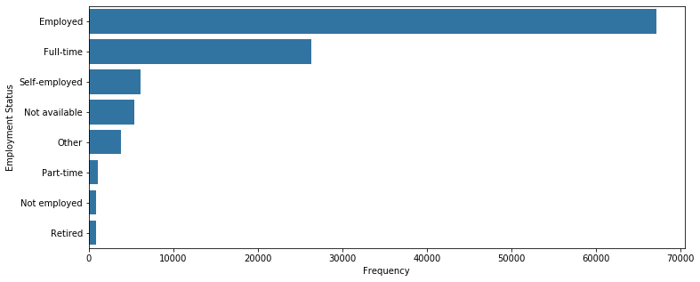

```python
plt.figure(figsize=[12,5])
sns.barplot(employment_status, employment_status.index.values, color=color)
plt.xlabel('Frequency')
plt.ylabel('Employment Status');
```

Most of the data concerns employed people (60%), full-time (24%). Not employed and retired people are at the end of the list (0.7% for each of these two groups). As with Listing Distribution, we are againg facing Not Avalable and Other values.

### EmploymentStatusDuration

How employment duration can be described?

```python
data['EmploymentStatusDuration'].describe()
```

```
count    106106.000000
mean         96.069346
std          94.486731
min           0.000000
25%          26.000000
50%          67.000000
75%         137.000000
max         755.000000
Name: EmploymentStatusDuration, dtype: float64
```

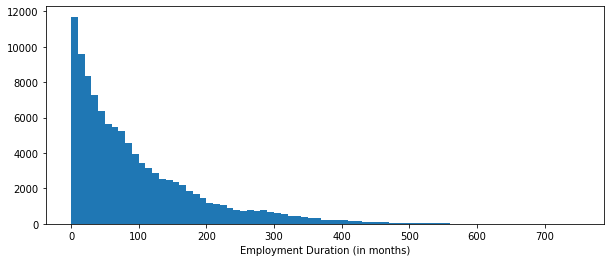

```python
plt.figure(figsize=[10,4])

bins = np.arange(data['EmploymentStatusDuration'].min(), data['EmploymentStatusDuration'].max(), 10)
plt.hist(data = data, x = "EmploymentStatusDuration",bins=bins)
plt.xlabel('Employment Duration (in months)');
```

### IncomeVerifiable

How many people provided proofs of their income?

```python
income_verif = data['IncomeVerifiable'].value_counts()

income_verif_rel = data['IncomeVerifiable'].value_counts(normalize=True)
income_verif_rel
```

```
True     0.923923
False    0.076077
Name: IncomeVerifiable, dtype: float64
```

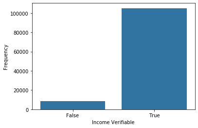

```python
sns.barplot(income_verif.index.values, income_verif, color=color)
plt.xlabel('Income Verifiable')
plt.ylabel('Frequency');
```

92% of the borroweres provided proofs of their income

### CurrentCreditLines

What is the distribution of current credit lines?

```python
data['CurrentCreditLines'].describe()
```

```
count    106127.000000
mean         10.317346
std           5.458249
min           0.000000
25%           7.000000
50%          10.000000
75%          13.000000
max          59.000000
Name: CurrentCreditLines, dtype: float64
```

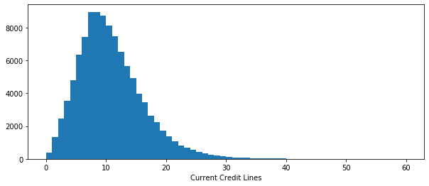

```python
plt.figure(figsize=[10,4])

bins = np.arange(data['CurrentCreditLines'].min(), data['CurrentCreditLines'].max()+2, 1)
plt.hist(data = data, x = "CurrentCreditLines",bins=bins)
plt.xlabel('Current Credit Lines');
```

### LoanOriginalAmount

How Loan Original Amount is distributed?

```python
data['LoanOriginalAmount'].describe()
```

```
count    113727.000000
mean       8337.289228
std        6245.987263
min        1000.000000
25%        4000.000000
50%        6500.000000
75%       12000.000000
max       35000.000000
Name: LoanOriginalAmount, dtype: float64
```

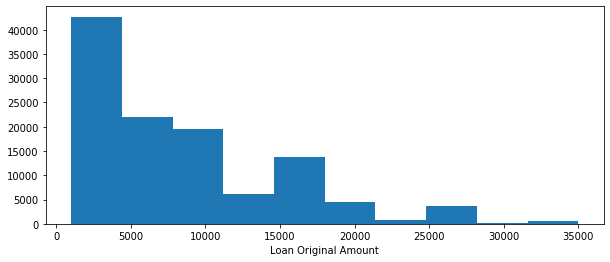

```python
plt.figure(figsize=[10,4])

plt.hist(data = data, x = "LoanOriginalAmount")
plt.xlabel('Loan Original Amount');
```

Loan original amount has a positively skewed distribution, low amounts are in generally borrowed more frequently

### Discuss the distribution(s) of your variable(s) of interest. Were there any unusual points? Did you need to perform any transformations?

I had to perform data groupping in order to avoid variables with low representation (Past Due for Loan Status). I also dropped very infrequent data (Cancelled and Final Payment in Progress always for Loan Status).

The one result that stroke me most is the shape of Prosper Score distribution - it is more or less normal, whereas I would expect is to be skewed, either positively, or negatively. It means that borrowers tend to take moderate risk, few of them don't risk at all, neither put all in.

### Of the features you investigated, were there any unusual distributions? Did you perform any operations on the data to tidy, adjust, or change the form of the data? If so, why did you do this?

Other and Not Available Values are disturbing in Employment Status. For a moment I kept them as is, since the presence of these values does not change figure interpretations for exploratory data analysis. However, I will need to remove these data for explanatory analysis

## Bivariate Exploration

In this section, we will investigate relationships between pairs of variables in the data.

Is the employment status correlated to numerical data?

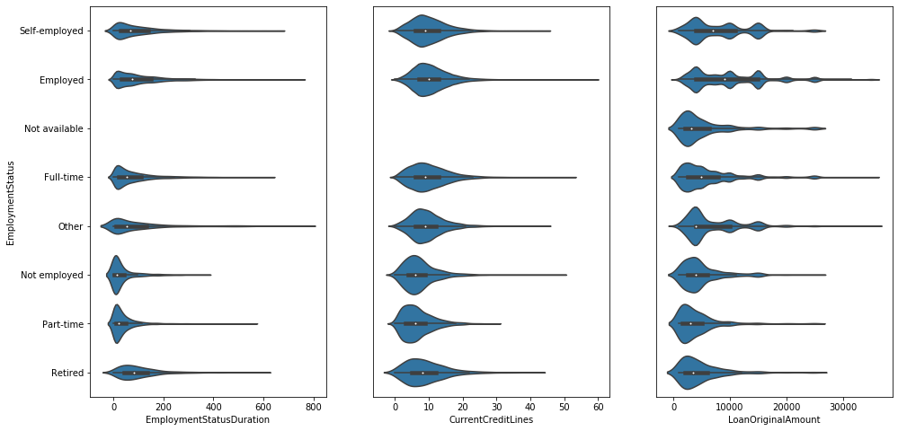

```python
plt.figure(figsize=[16,8])

plt.subplot(1,3,1)
sns.violinplot(data=data, x='EmploymentStatusDuration', y='EmploymentStatus',color=color);

ax = plt.subplot(1,3,2)
sns.violinplot(data=data, x='CurrentCreditLines', y='EmploymentStatus',color=color)
y_axis = ax.axes.get_yaxis()
y_axis.set_visible(False)
ax.set_yticklabels([]);

ax = plt.subplot(1,3,3)
sns.violinplot(data=data, x='LoanOriginalAmount', y='EmploymentStatus',color=color)
y_axis = ax.axes.get_yaxis()
y_axis.set_visible(False)
ax.set_yticklabels([]);
```

Employment status seems to be related to employment duration: not employed or part-time employed status corresponds to low employment status duration (short period of time unemployed or part-time), self-employed, employed, ful time - higher duration.

Is Prosper Score correlated to quantitative data?

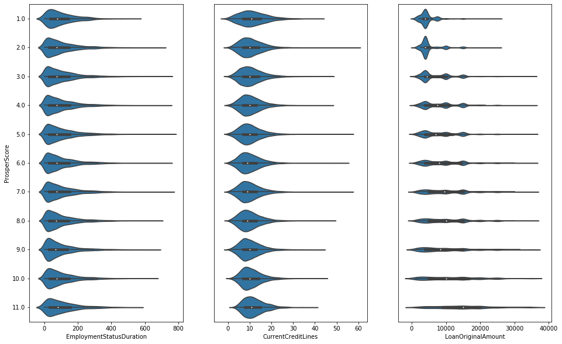

```python
plt.figure(figsize=[16,10])

plt.subplot(1,3,1)
sns.violinplot(data=data, x='EmploymentStatusDuration', y='ProsperScore',color=color);

ax = plt.subplot(1,3,2)
sns.violinplot(data=data, x='CurrentCreditLines', y='ProsperScore',color=color)
y_axis = ax.axes.get_yaxis()
y_axis.set_visible(False)
ax.set_yticklabels([]);

ax = plt.subplot(1,3,3)
sns.violinplot(data=data, x='LoanOriginalAmount', y='ProsperScore',color=color)
y_axis = ax.axes.get_yaxis()
y_axis.set_visible(False)
ax.set_yticklabels([]);
```

```python
data.groupby(['ProsperScore']).mean()['LoanOriginalAmount']
```

```
ProsperScore
1.0      4567.562626
2.0      5282.640084
3.0      7060.091971
4.0      8405.321954
5.0      8399.263895
6.0      9225.482494
7.0     10102.347037
8.0     10486.086815
9.0     10053.964482
10.0    11744.683055
11.0    14872.346180
Name: LoanOriginalAmount, dtype: float64
```

There is indeed a correlation between Prosper Score and Loan Original amount - the higher the amount, the higher the score.

Is there a correlation between Employment Status and proofs of income?

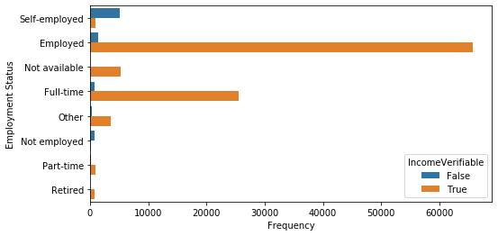

```python
plt.figure(figsize=[8,4])
sns.countplot(data = data, y = 'EmploymentStatus', hue = 'IncomeVerifiable')
plt.xlabel('Frequency')
plt.ylabel('Employment Status');
```

It is quite expected that self-employed people would have more difficulties in providung proofs for their income.

Now, we would loke to assess the distribution of Prosper Score by Employment status. Since both are categorical with a lot of unique values, we will use a heatmap instead of clustered bar chart.

Some additional preparation is needed for this

```python
# data preparation
empl_prosp = data.groupby(['EmploymentStatus', 'ProsperScore']).size()
empl_prosp = empl_prosp.reset_index(name='count')
empl_prosp = empl_prosp.pivot(index = 'EmploymentStatus', columns = 'ProsperScore', values = 'count')
empl_prosp
```

| ProsperScore EmploymentStatus | 1.0 | 2.0 | 3.0 | 4.0 | 5.0 | 6.0 | 7.0 | 8.0 | 9.0 | 10.0 | 11.0 |
| --- | --- | --- | --- | --- | --- | --- | --- | --- | --- | --- | --- |
| Employed | 532 | 4332 | 5934 | 10159 | 7786 | 10106 | 8792 | 9675 | 4692 | 3763 | 1362 |
| Full-time | 198 | 244 | 331 | 477 | 710 | 883 | 920 | 1571 | 1810 | 759 | 14 |
| Not available | 0 | 0 | 0 | 0 | 0 | 0 | 0 | 0 | 0 | 0 | 0 |
| Not employed | 4 | 52 | 76 | 106 | 104 | 118 | 88 | 71 | 27 | 3 | 0 |
| Other | 37 | 373 | 508 | 755 | 516 | 574 | 408 | 374 | 126 | 93 | 34 |
| Part-time | 6 | 9 | 9 | 19 | 32 | 24 | 33 | 51 | 59 | 14 | 0 |
| Retired | 13 | 27 | 19 | 32 | 40 | 52 | 53 | 49 | 58 | 24 | 0 |
| Self-employed | 200 | 706 | 745 | 1019 | 600 | 496 | 287 | 223 | 126 | 83 | 43 |

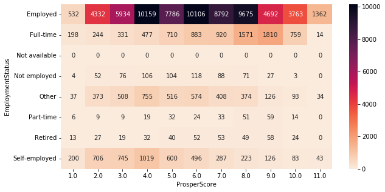

```python
plt.figure(figsize=[10,5])
sns.heatmap(empl_prosp, annot = True, fmt = 'd', cmap='rocket_r');
```

The highest prosper score is evenly distributed across different subsets of data - 4 to 8 prosper scores are found more frequently in general, than 1-3 or 9-11. Some tendencies emerge: full-time employed people tend to take lower ris, and self-employed people tend to take higher risks.

Is there differences in Prosper Score distribution across differnt loan status?

```python
# data preparation
prosp_loan = data.groupby(['LoanStatus','ProsperScore']).size()
prosp_loan = prosp_loan.reset_index(name='count')
prosp_loan = prosp_loan.pivot(index = 'LoanStatus', columns = 'ProsperScore', values = 'count')
prosp_loan
```

| ProsperScore LoanStatus | 1.0 | 2.0 | 3.0 | 4.0 | 5.0 | 6.0 | 7.0 | 8.0 | 9.0 | 10.0 | 11.0 |
| --- | --- | --- | --- | --- | --- | --- | --- | --- | --- | --- | --- |
| Chargedoff | 235 | 377 | 414 | 784 | 907 | 925 | 662 | 666 | 309 | 57 | 0 |
| Completed | 341 | 848 | 1077 | 1828 | 2212 | 2847 | 2357 | 3711 | 2836 | 1576 | 31 |
| Current | 337 | 4196 | 5804 | 9476 | 6222 | 7981 | 7210 | 7265 | 3612 | 3054 | 1419 |
| Defaulted | 37 | 70 | 75 | 119 | 165 | 173 | 135 | 139 | 71 | 20 | 1 |
| Past Due | 40 | 252 | 252 | 360 | 282 | 327 | 217 | 233 | 70 | 32 | 2 |

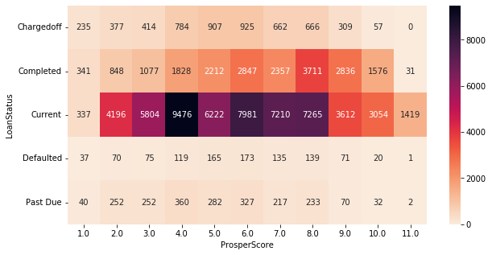

```python
plt.figure(figsize=[10,5])
sns.heatmap(prosp_loan, annot = True, cmap='rocket_r', fmt='g');
```

Prosper score is again normally distributed across all the subsets, with prevalence in current and completed loan status

Does the distribution of Loan Status changes within different Employment Status groups?

```python
# data preparation
empl_loan = data.groupby(['EmploymentStatus', 'LoanStatus']).size()
empl_loan = empl_loan.reset_index(name='count')
empl_loan = empl_loan.pivot(index = 'EmploymentStatus', columns = 'LoanStatus', values = 'count')
empl_loan
```

| LoanStatus EmploymentStatus | Chargedoff | Completed | Current | Defaulted | Past Due |
| --- | --- | --- | --- | --- | --- |
| Employed | 3529.0 | 12332.0 | 48929.0 | 630.0 | 1725.0 |
| Full-time | 5343.0 | 17397.0 | 1316.0 | 2217.0 | 71.0 |
| Not available | 1065.0 | 3077.0 | NaN | 1204.0 | NaN |
| Not employed | 190.0 | 344.0 | 248.0 | 27.0 | 26.0 |
| Other | 295.0 | 449.0 | 2882.0 | 54.0 | 118.0 |
| Part-time | 202.0 | 794.0 | 24.0 | 60.0 | 8.0 |
| Retired | 180.0 | 459.0 | 92.0 | 58.0 | 6.0 |
| Self-employed | 897.0 | 1783.0 | 3085.0 | 246.0 | 113.0 |

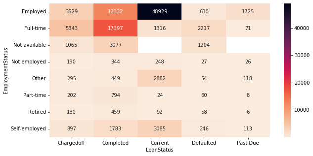

```python
plt.figure(figsize=[10,5])
sns.heatmap(empl_loan, annot = True, cmap='rocket_r', fmt='g');
```

### Did you observe any interesting relationships between the other features (not the main feature(s) of interest)?

I found it interesting and at the same time no surprising that Employment Status is correlated to Employment Status Duration. For example, not employed and part-time employed status both have the lowest duration, indeed, it may be considered as a transition status. On the contrary, self-employed, employed and full-time employed status have a longer duration.

Another interesting (and also non surprising discovery) was the correlation between Employment Status and the ability to prove this status: self-employed people have more problemns than other groups in providing such documentation.

## Multivariate Exploration

Here we will create plots of three or more variables to investigate the data even further.

```python
# numeric variables
numeric_vars = ['EmploymentStatusDuration', 'CurrentCreditLines', 'LoanOriginalAmount']
```

First, we will assess the distribution of Employement Status Duration, Current Credit Lines and Loan Original Amount

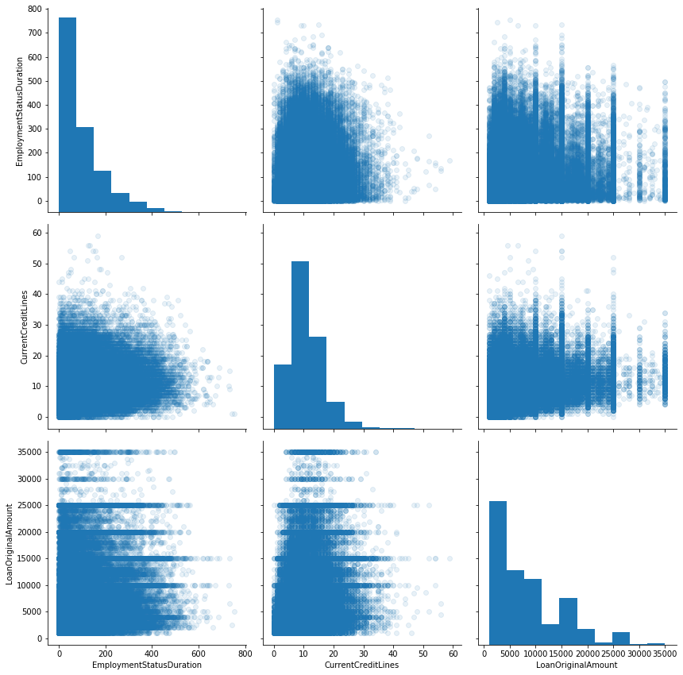

```python
# Faceting
g = sns.PairGrid(data = data, vars = numeric_vars, height = 4)
g = g.map_diag(plt.hist)
g.map_offdiag(plt.scatter, alpha = 1/10);
```

There is a slight positive correlation between Current Credit Lines and Loan Original Amount.

Next we will assess the distribution on Prosper Score across both Current Credit Lines and Loan Original Amount

[figure not shown]

```python
g = sns.FacetGrid(data = data, hue = 'ProsperScore', height = 5, aspect=2, palette = 'viridis')
g.map(sns.regplot, 'CurrentCreditLines', 'LoanOriginalAmount', fit_reg=False, scatter_kws={'alpha':0.5})
g.add_legend()
plt.xlabel('Current Credit Lines')
plt.ylabel('Loan Status');
```

No appearent correlation is found, probably because of high range of Prosper Score Values the data was overplotted.

Is there any intersting trends emerging if we combine Prosper Score and Loan Status and analyze them both in terms of Original Loan Amount?

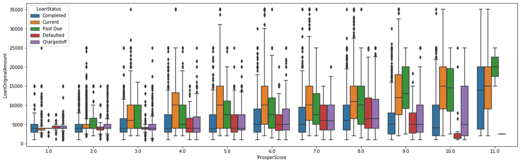

```python
plt.figure(figsize=[20,6])
sns.boxplot(data = data, x = 'ProsperScore', y = 'LoanOriginalAmount', hue = 'LoanStatus');
```

The data globally follows the same trend: the higher the Prosper Score, the higher is the amount, and the more variance is encountered.

What about the Original Loan Amount and its distribution across Prosper Score combined with Employment Status?

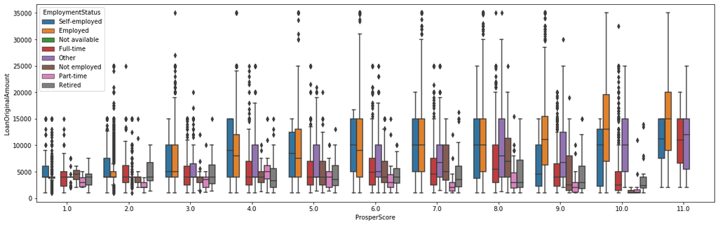

```python
plt.figure(figsize=[20,6])
sns.boxplot(data = data, x = 'ProsperScore', y = 'LoanOriginalAmount', hue = 'EmploymentStatus');
```

### Were there any interesting or surprising interactions between features?

It was dissapointing to see that quantitative data does not show much trends, both in bivariate and multivariate exploration. I probably have chosen numeric feature that are of no interest for this investigation.